# Clustering on The Earthquake Data

Nicholas Jacob

11/22/2021

## Clustering

I will use the same data from wikipedia on earthquakes in 2021 that I gathered [here](https://en.wikipedia.org/wiki/List_of_earthquakes_in_2021). The previous portion of this project was published [here](https://nurfnick.github.io/Data_Mining_R/EarthQuakes.html) and the association portion of the project can be found [here](https://nurfnick.github.io/Data_Mining_R/EarthQuakesAssociation.html) I have not included all the data cleaning in this document even though it was all necessary. It is hidden in the first cell!

For clustering to work well, I can only pass numerical data that has been normalized. By data contains numeric values, I will examine `Deaths, Injuries, Depth and Mw` to see if I can identify clusters.

```r
df_numeric <- df %>%
  select("Deaths", "Injuries", "Depth", "Mw")
head(df_numeric)
```

```
## # A tibble: 6 × 4
##   Deaths Injuries Depth    Mw
##    <int>    <int> <dbl> <dbl>
## 1      0        0  21     6.1
## 2      0        0  37.1   6.2
## 3      0        0  10     4.7
## 4      0        0 148     6.1
## 5      0        0 224     6.3
## 6      0        0 113     6.1
```

Time to normalize!

```r
df_scaled <- as.data.frame(scale(df_numeric))

head(df_scaled)
```

```
##        Deaths   Injuries      Depth         Mw
## 1 -0.07776099 -0.1001685 -0.2638460  0.1019067
## 2 -0.07776099 -0.1001685 -0.1043864  0.2491052
## 3 -0.07776099 -0.1001685 -0.3727935 -1.9588729
## 4 -0.07776099 -0.1001685  0.9940026  0.1019067
## 5 -0.07776099 -0.1001685  1.7467309  0.3963038
## 6 -0.07776099 -0.1001685  0.6473514  0.1019067
```

I think the `scale` function did as I intended but let’s do this with the tidyverse just to be consistent and see my results.

```r
df <-
  df %>% mutate(
  Deaths = scale(Deaths),
  Injuries = scale(Injuries),
  Mw = scale(Mw),
  Depth = scale(Depth)
)

df %>% summarise_if(is.numeric, c(mean = mean, standard_deviation = sd), na.rm = TRUE)
```

```
## # A tibble: 1 × 10
##   Day_mean Deaths_mean Injuries_mean  Mw_mean Depth_mean Day_standard_deviation
##      <dbl>       <dbl>         <dbl>    <dbl>      <dbl>                  <dbl>
## 1     13.6   -4.50e-19     -1.16e-18 1.01e-16   3.29e-17                   8.19
## # … with 4 more variables: Deaths_standard_deviation <dbl>,
## #   Injuries_standard_deviation <dbl>, Mw_standard_deviation <dbl>,
## #   Depth_standard_deviation <dbl>
```

Looks like it did exactly as I intended. Now I’ll pass it to the $K$-means clustering algorithm in base R.

```r
km <- df %>%
  select("Deaths", "Injuries", "Depth", "Mw")  %>%
  kmeans(centers = 4, nstart = 5)
km
```

```
## K-means clustering with 4 clusters of sizes 10, 142, 42, 1
##
## Cluster means:
##        Deaths    Injuries      Depth         Mw
## 1 -0.07776099 -0.10016853  3.8391174  0.4993428
## 2 -0.06989312 -0.06088509 -0.1623616  0.3838645
## 3 -0.07554424 -0.08951003 -0.3562627 -1.4576969
## 4 13.87529077 13.40678996 -0.3727935  1.7210907
##
## Clustering vector:
##   [1] 2 2 3 2 2 2 2 2 3 2 2 2 3 2 2 3 2 3 3 2 3 2 2 2 2 2 2 2 2 2 2 2 3 2 2 2 3
##  [38] 2 2 2 3 3 3 2 2 2 2 2 2 2 2 2 2 2 2 2 3 3 2 2 2 2 2 2 3 2 3 1 2 2 3 2 2 1
##  [75] 2 2 2 2 1 1 2 3 2 2 2 3 2 2 1 2 2 2 2 2 3 3 2 2 2 2 2 3 2 2 3 3 3 2 2 2 3
## [112] 3 1 2 2 2 2 2 2 2 2 2 2 2 2 3 2 2 2 2 2 2 2 2 2 3 2 2 4 2 2 2 2 2 2 2 2 2
## [149] 3 2 2 3 2 3 2 2 2 2 2 2 3 3 1 3 1 2 3 3 2 2 3 2 1 3 2 2 2 2 3 2 1 2 2 2 2
## [186] 2 3 2 2 2 2 2 2 2 3
##
## Within cluster sum of squares by cluster:
## [1] 18.42569 99.19882 11.92690  0.00000
##  (between_SS / total_SS =  83.3 %)
##
## Available components:
##
## [1] "cluster"      "centers"      "totss"        "withinss"     "tot.withinss"
## [6] "betweenss"    "size"         "iter"         "ifault"
```

Let’s visualize our clusters in some 2D graphs.

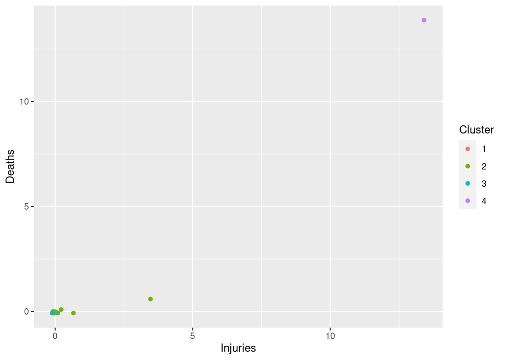

```r
df <- df %>% add_column(Cluster = as.factor(km$cluster))

ggplot(df, aes(x = Injuries, y = Deaths, color = Cluster)) +
  geom_point()
```

Clearly we are seeing a cluster for that giant outlier. Perhaps if I remove that outlier it will clear up some of this analysis.

```r
dfNoOut <- df %>% filter(!abs(Deaths)>3, #more than 3 sd's away from the mean
              !abs(Injuries)>3,
              !abs(Mw)>3,
              !abs(Depth)>3)

dfNoOut %>% head()
```

```
## # A tibble: 6 × 10
##   Month     Day Country  Deaths[,1] Injuries[,1] Mw[,1] Depth[,1] MMI   Offshore
##   <fct>   <int> <fct>         <dbl>        <dbl>  <dbl>     <dbl> <fct> <fct>
## 1 January     3 United …    -0.0778       -0.100  0.102    -0.264 VI    offshore
## 2 January     6 New Zea…    -0.0778       -0.100  0.249    -0.104 IV    offshore
## 3 January     6 Croatia     -0.0778       -0.100 -1.96     -0.373 VIII  on land
## 4 January     6 Indones…    -0.0778       -0.100  0.102     0.994 IV    offshore
## 5 January     8 New Zea…    -0.0778       -0.100  0.396     1.75  IV    offshore
## 6 January     8 Vanuatu     -0.0778       -0.100  0.102     0.647 IV    offshore
## # … with 1 more variable: Cluster <fct>
```

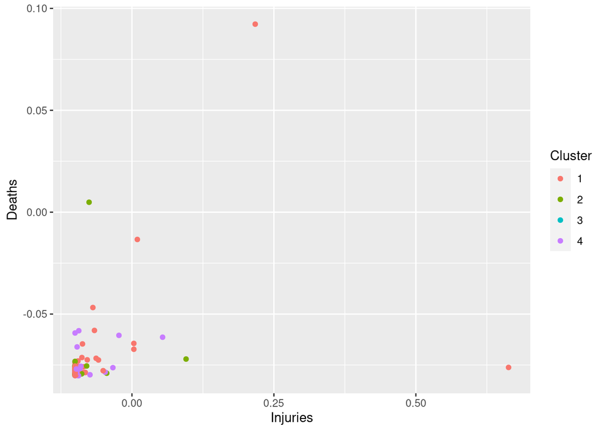

```r
km <- dfNoOut %>%
  select("Deaths", "Injuries", "Depth", "Mw")  %>%
  kmeans(centers = 4, nstart = 5)

dfNoOut <- dfNoOut %>% mutate(
  Cluster = as.factor(km$cluster)
)

ggplot(dfNoOut, aes(x = Injuries, y = Deaths, color = Cluster)) +
  geom_jitter()
```

Well after all that, I still don’t see the clusters… Attepmting to visualize the 4D data with only two of the variables is part of the issue!